# SeniorRH

Hackathon DSN

14 et 15 Mai 2024

# Suivre la situation RH des établissements PA en quasi temps réel 👵 👴

- Utilisateurs : Pour les ARS, les conseils départementaux , l’administration centrale
- Objectifs : Identifier rapidement les établissements où la situation RH se dégrade et met en péril la qualité de soin des PA
- Proposition de valeur Vérifier que le nombre de personnel soignant et leur qualification correspond aux exigences attendues en matière d’accueil des PA

# Un Outil BI avec de la donnée de qualité, exhaustive et fraîche

- Tirer partie des richesses de la DSN 💸
- Construire et rassembler les indicateurs pertinents à la caractérisation de la situation RH à un instant donné 📈

# Impacts attendus 🎉

- Avoir une référence unique qui fasse consensus sur l’emploi et les conditions de travail
- Limiter la charge de collecte auprès des établissements multi-sollicités par des enquêtes nombreuses et pilotées par des acteurs peu coordonnés
- De la donnée plus régulière (ex: enquête DREES = tous les 4 ans)

# Difficultés et prolongements

- Retravailler: les nombreux contrats courts de un jour et la prise en compte de l’emploi intérimaire
- Ajouter : des indicateurs sur les arrêts de travail, quotité, autres conditions de travail
- Apparier: Proxy via l’APET, un outil exhaustif utiliserait plutôt FINESS, à rapprocher des SIRET de la DSN
- Expertiser: les limites statistiques des indicateurs proposés

# Les mésanges bleues à Déesse (Aisne)

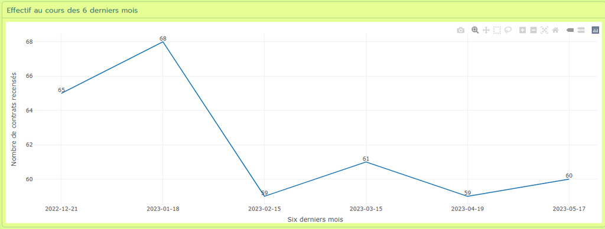

# Les mésanges bleues à Déesse (Aisne)

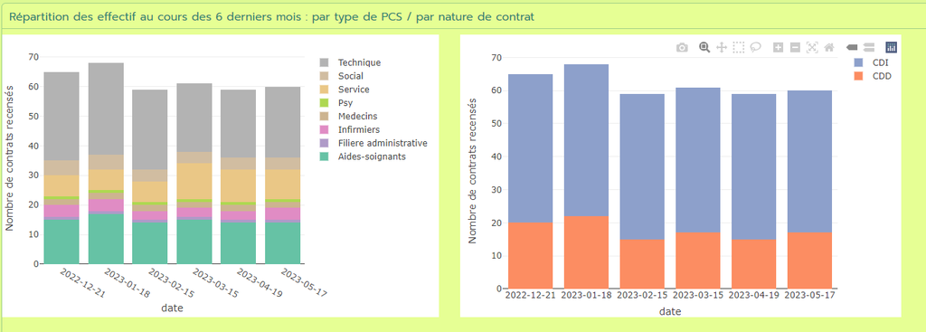

# Les mésanges bleues à Déesse (Aisne)

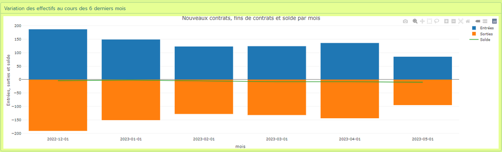

# Les mésanges bleues à Déesse (Aisne)

|  | Motif de rupture | Sur les 6 derniers mois | evol | Le dernier mois |
| --- | --- | --- | --- | --- |
| 1 | fin de contrat à durée déterminée ou fin d'accueil occasionnel | 31.7 | 12.4 | 42 |
| 2 | démission | 0.3 | 0.8 | 1 |
| 3 | licenciement pour inaptitude physique d'origine non professionnelle | 0.2 | -0.2 | 0 |

# Merci à l’organisation et bravo à tous 🙌

Prototype à télécharger [sur notre fork nelissanne/hackathon-dsn](https://github.com/nelissanne/hackathon-dsn/blob/main/senioRH_app.html) 👌